# Predictions for dual task experiment

Pierce Edmiston

2015-10-29

If we want big effects with the mask, I think we need to embrace a task that more explicitly requires visual imagery, show big effects of the mask, and put it as Experiment 1. I think it will allow us to leverage the nuance of the property verification experiments: they demonstrate that the disruption is specific to visual and not encyclopedic knowledge in a task that does not explicitly require vision. In Experiment 3, the orientation discrimination experiments demonstrate that the mask does not just make performance on visual tasks worse, it reduces both the positives and the negatives of thinking about what something looks like (because in the task you might think about the wrong thing and therefore imagery hurts performance). In the follow ups Experiments 3B and 3C, we demonstrate that the interference is modality specific, and does not need to presented simultaneously to the cues in order to be effective.

Ok, so what is the visual imagery task? How about this:

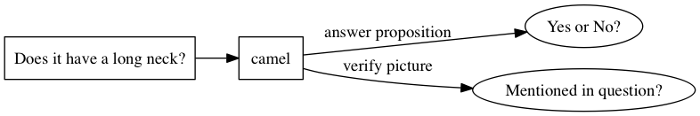

On each trial, participants hear one of the questions, e.g., “Does it have a flat surface?” followed by a cue, “table”. On most of the trials, after the cue they are presented a prompt for them to answer the question, making this experiment just like the existing one, with the addition of the longer mask presented during the question and cue intervals.

The difference is that on a subset of the trials, instead of a prompt they are presented a picture. They still respond “yes” or “no”, but this time they are identifying whether or not the picture was named by the cue.

The addition of these picture trials does a number of things to expand our findings from the other experiments.

1. It makes this a dual task experiment, which makes it harder, increasing overall error rates and likely the effect of the mask as well.
2. It forces people to look at the screen during the trial (which is my biggest concern with regard to making all of the stimuli auditory).
3. It encourages people to visualize the objects. As I said, the goal of this experiment is to embrace visual imagery, and show that the mask has a huge effect. The remaining experiments systematically remove all incentives to visualize. In Experiment 2, we remove the picture trials, and in Experiment 3 we remove the benefit of visualizing altogether.

So what are we going to find? First imagine this task on the visual feature trials. You hear a question like “Does it have a flat surface?” and you’re imagining flat surfaces. You get the cue “table” and you’re definitely picturing a table because doing so makes it easier both to answer the question and to verify a picture of a possible table. The mask makes all of this harder to do.

Now imagine an encyclopedic feature trial. You hear a question like “Does it live in Africa?” and get “zebra”. What is the mask going to make harder, answering the proposition or verifying a picture of a zebra?

I’m predicting the mask will only make verifying the picture harder. Answering an encyclopedic question will not be any harder when the mask is present, but verifying a picture of the named object will still be affected by the mask.

Here’s something else I like about this design. We can compare responses to the prompts independent of the picture verification trials to the same questions in the original property verification experiment. That way we can measure directly the effect of the dual task on baseline performance.

We’ll still find the interaction such that responses to visual questions are more negatively affected by the mask than responses to non visual questions.

But if there is any effect of the secondary, visual task (the possibility that some trials might involve picture verification), I bet we’ll see it on the encyclopedic feature trials. I think the secondary, visual task will decrease baseline performance on the encyclopedic questions.

If we show that making encyclopedic feature questions harder (by having some picture verification catch trials) still doesn’t make the mask disrupt performance, then the Reviewer’s point that the effect of the mask is contingent on overall difficulty of the question (and not modality of the knowledge) doesn’t hold.

# Picture verification trials

```
##        question_type mask_type feat_type error_rate
## 1 Answer proposition    nomask    visual      0.051
## 2 Answer proposition      mask    visual      0.150
## 3 Answer proposition    nomask nonvisual      0.049
## 4 Answer proposition      mask nonvisual      0.070
## 5     Verify picture    nomask    visual      0.010
## 6     Verify picture      mask    visual      0.080
## 7     Verify picture    nomask nonvisual      0.040
## 8     Verify picture      mask nonvisual      0.070
```

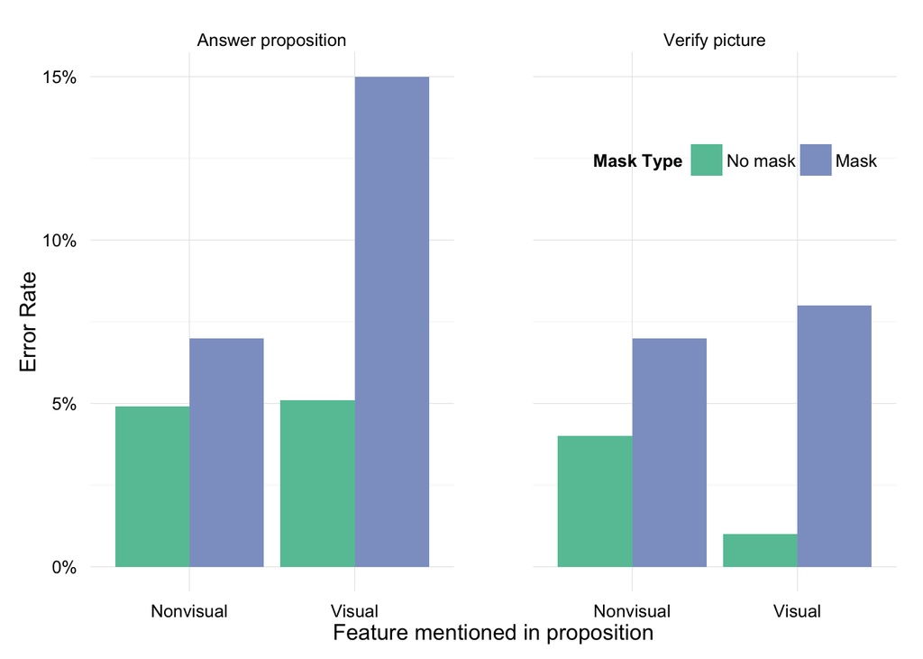